# 7_Factors_Dates_Times

#### 2.

Most common religion and party affiliation

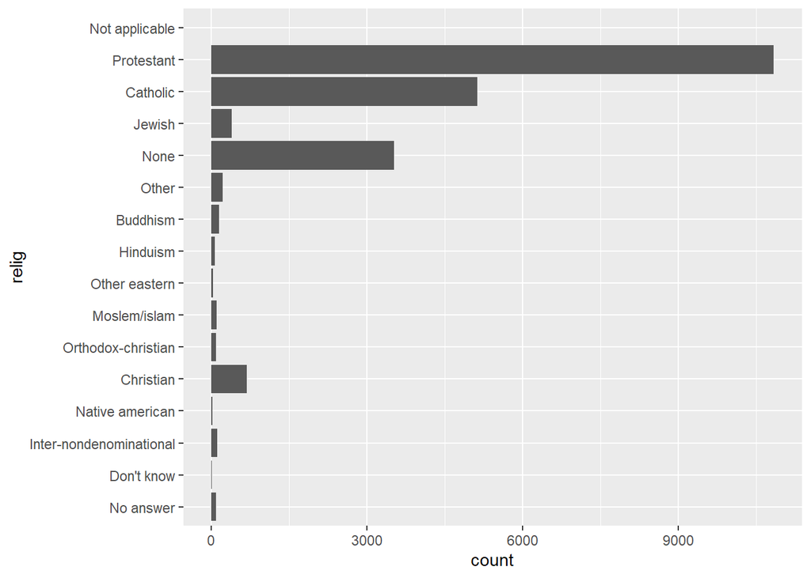

```r
ggplot(gss_cat, aes(x = relig)) +
  geom_bar() +
  scale_x_discrete(drop = FALSE) +
  coord_flip()
```

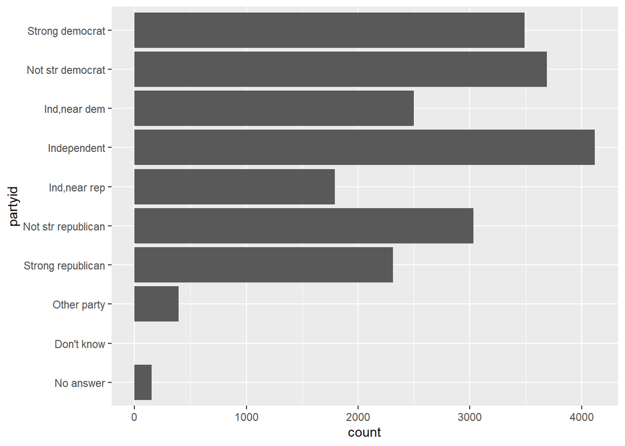

```r
ggplot(gss_cat, aes(x = partyid)) +
  geom_bar() +
  scale_x_discrete(drop = FALSE) +
  coord_flip()
```

The most common religion is protestant while the highest reported party identification is Independent.

#### 3.

```r
gss_cat %>%
  count(relig, denom) %>%
  arrange(desc(n))
```

### Changing Factor Order

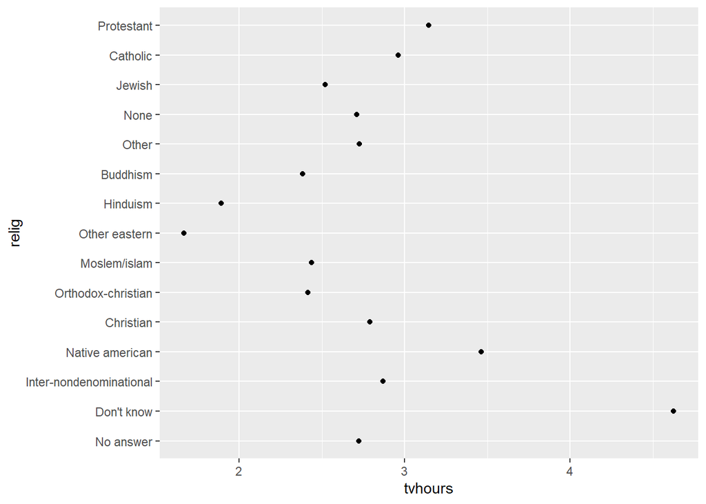

```r
relig_summary <- gss_cat %>%
  group_by(relig) %>%
  summarise(
    age = mean(age, na.rm = TRUE),
    tvhours = mean(tvhours, na.rm = TRUE),
    n = n())

ggplot(relig_summary, aes(x = tvhours, y = relig)) +
  geom_point()
```

This graph is hard to interpret, no clear pattern. So we reorder.

### fct_reorder

Needs:factor you want to reorder, x numberic vector as a basis for reordering, optional function (default is median)

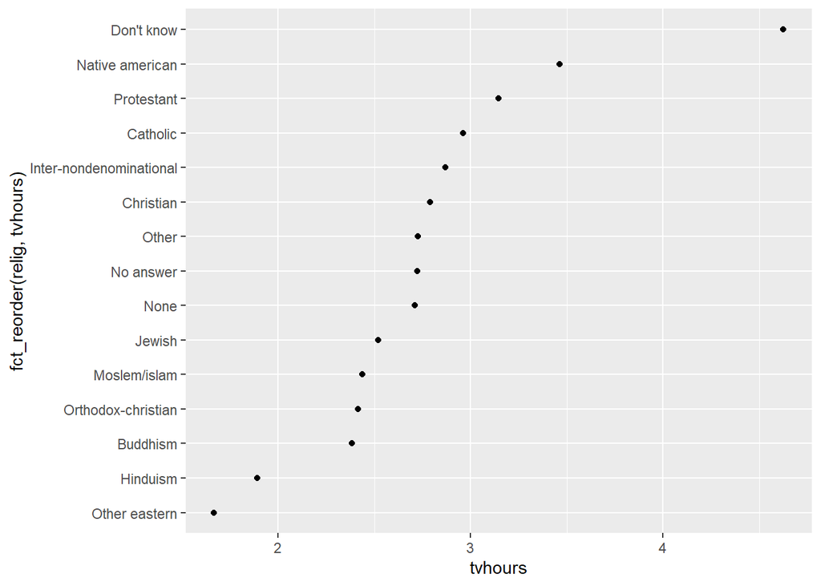

```r
ggplot(relig_summary, aes(x = tvhours, y = fct_reorder(relig, tvhours))) +
  geom_point()
```

This shows that Eastern religions tend to watch less tv than Western religions. Keeping in mind that this survey is self reported. Additionally, it may be better to mutate the factor reorder before the ggplot, simplifying the GGPLOT call.

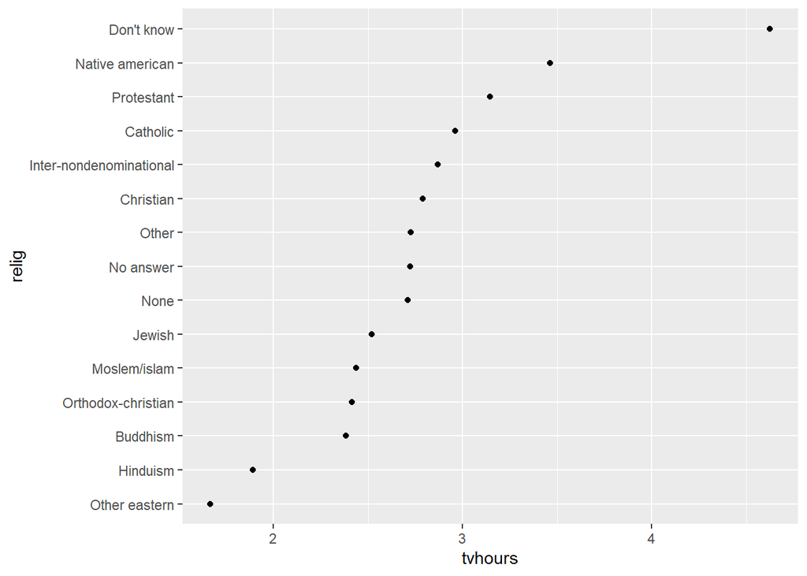

```r
relig_summary %>%
  mutate(relig = fct_reorder(relig, tvhours)) %>%
  ggplot(aes(x = tvhours, y = relig)) +
  geom_point()
```

Do older people have more income? The following code shows age and income, but just because you can do something, doesn’t mean you should. The second graph illstrates a better graphic with less code.

```r
rincome_summary <- gss_cat %>%
  group_by(rincome) %>%
  summarise(
    age = mean(age, na.rm = TRUE),
    tvhours = mean(tvhours, na.rm = TRUE),
    n = n()
  )

rincome_summary
```

```
## # A tibble: 16 x 4
##    rincome          age tvhours     n
##    <fct>          <dbl>   <dbl> <int>
##  1 No answer       45.5    2.90   183
##  2 Don't know      45.6    3.41   267
##  3 Refused         47.6    2.48   975
##  4 $25000 or more  44.2    2.23  7363
##  5 $20000 - 24999  41.5    2.78  1283
##  6 $15000 - 19999  40.0    2.91  1048
##  7 $10000 - 14999  41.1    3.02  1168
##  8 $8000 to 9999   41.1    3.15   340
##  9 $7000 to 7999   38.2    2.65   188
## 10 $6000 to 6999   40.3    3.17   215
## 11 $5000 to 5999   37.8    3.16   227
## 12 $4000 to 4999   38.9    3.15   226
## 13 $3000 to 3999   37.8    3.31   276
## 14 $1000 to 2999   34.5    3.00   395
## 15 Lt $1000        40.5    3.36   286
## 16 Not applicable  56.1    3.79  7043
```

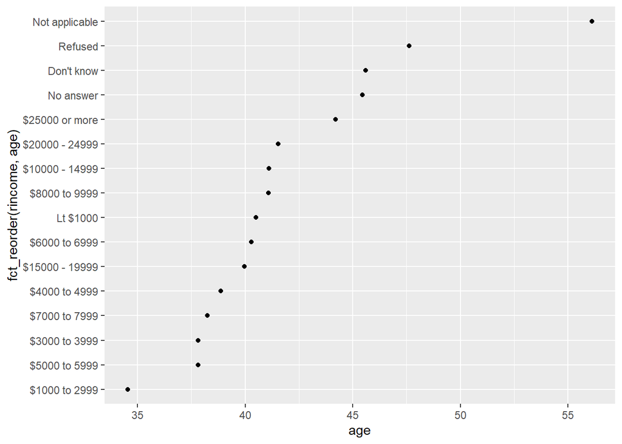

```r
ggplot(rincome_summary, aes(x = age, y = fct_reorder(rincome, age)))+
  geom_point()
```

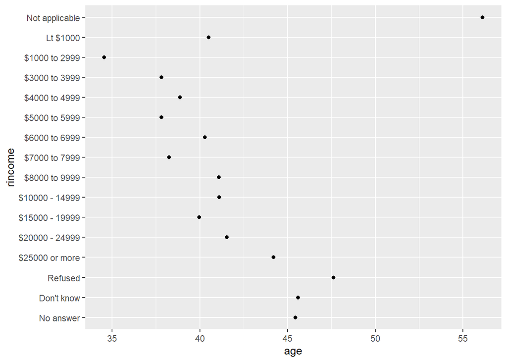

```r
ggplot(rincome_summary, aes(age, rincome)) +
  geom_point()
```

### Re-ordering for line plots

```r
by_age <- gss_cat %>%
  filter(!is.na(age)) %>%
  count(age, marital) %>%
  group_by(age) %>%
  mutate(prop = n / sum(n))

by_age
```

```
## # A tibble: 351 x 4
## # Groups:   age [72]
##      age marital           n    prop
##    <int> <fct>         <int>   <dbl>
##  1    18 Never married    89 0.978
##  2    18 Married           2 0.0220
##  3    19 Never married   234 0.940
##  4    19 Divorced          3 0.0120
##  5    19 Widowed           1 0.00402
##  6    19 Married          11 0.0442
##  7    20 Never married   227 0.904
##  8    20 Separated         1 0.00398
##  9    20 Divorced          2 0.00797
## 10    20 Married          21 0.0837
## # ... with 341 more rows
```

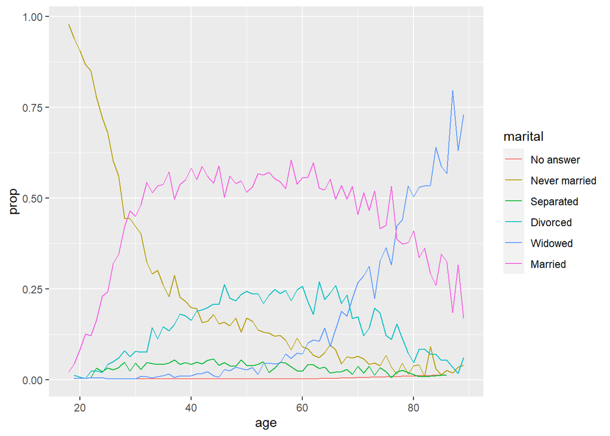

```r
ggplot(by_age, aes(age, prop, colour = marital)) +
  geom_line(na.rm = TRUE)
```

recalling that ! means does not, so those values not = NA. The marital status by colour is hard to read so.

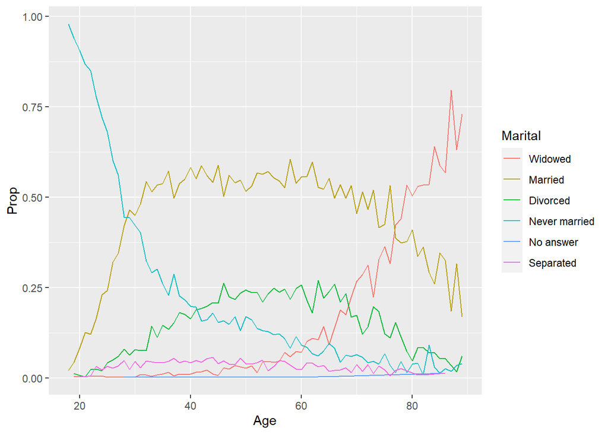

```r
ggplot(by_age, aes(age, prop,
                   colour = fct_reorder2(marital, age, prop))) +
  geom_line(na.rm = TRUE) +
  labs(colour = "Marital", y = "Prop", x = "Age")
```

So we re-order the colour key to match proportions at top of age range and re-label the axis for clarities sake.

### Re-ordering with bar-plots

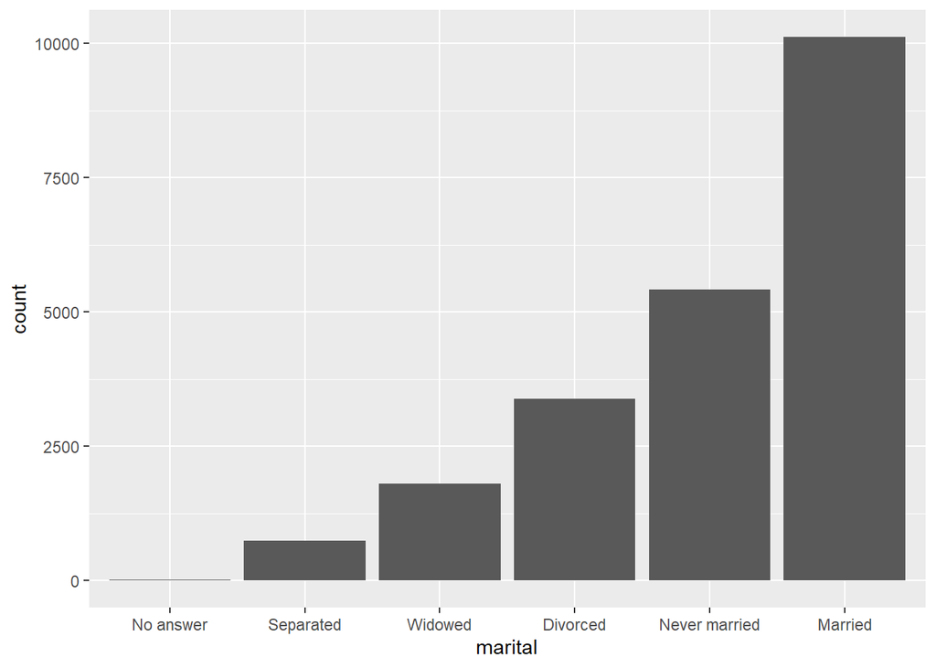

```r
gss_cat %>%
  mutate(marital = marital %>% fct_infreq() %>% fct_rev()) %>%
  ggplot(aes(marital)) +
    geom_bar()
```

### Exercises 15.4.1

#### 1. TV hours

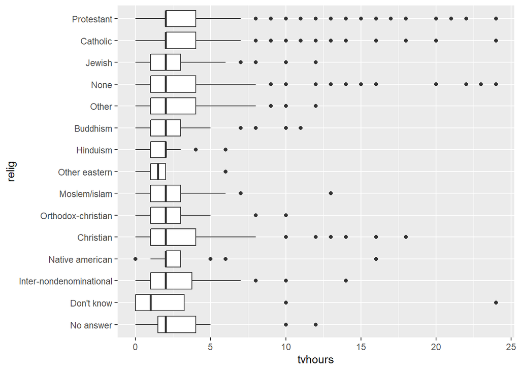

```r
gss_cat %>%
ggplot(aes(relig, tvhours)) +
  geom_boxplot() +
  coord_flip()
```

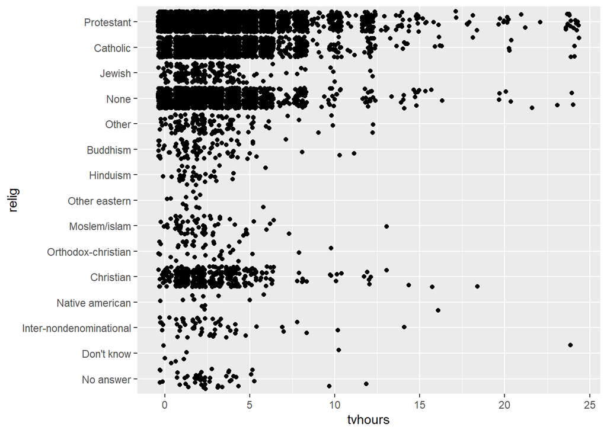

```r
gss_cat %>%
ggplot(aes(relig, tvhours)) +
  geom_jitter() +
  coord_flip()
```

If we change the mean to median the interpretation of the data is completely different. Can change the religion summary from mean to median to demonstrate this.

#### 2. levels of gss_cat

Examining the levels i.e. arbitrary or principled in this data set.

```r
levels(gss_cat$rincome)
```

```
##  [1] "No answer"      "Don't know"     "Refused"        "$25000 or more"
##  [5] "$20000 - 24999" "$15000 - 19999" "$10000 - 14999" "$8000 to 9999"
##  [9] "$7000 to 7999"  "$6000 to 6999"  "$5000 to 5999"  "$4000 to 4999"
## [13] "$3000 to 3999"  "$1000 to 2999"  "Lt $1000"       "Not applicable"
```

```r
levels(gss_cat$marital)
```

```
## [1] "No answer"     "Never married" "Separated"     "Divorced"
## [5] "Widowed"       "Married"
```

So the reported income is ordered logically, but the martial status could be ordered in many ways.

## Modifying Factor Levels

The most powerful tool for this is fct_recode. Allows to clarify labels, collapse levels i.e. income in gss

```r
gss_cat %>% count(partyid)
```

```
## # A tibble: 10 x 2
##    partyid                n
##    <fct>              <int>
##  1 No answer            154
##  2 Don't know             1
##  3 Other party          393
##  4 Strong republican   2314
##  5 Not str republican  3032
##  6 Ind,near rep        1791
##  7 Independent         4119
##  8 Ind,near dem        2499
##  9 Not str democrat    3690
## 10 Strong democrat     3490
```

So we can change this so that it’s sensible

```r
gss_cat %>%
  mutate(partyid = fct_recode(partyid,
    "Republican, strong"    = "Strong republican",
    "Republican, weak"      = "Not str republican",
    "Independent, near rep" = "Ind,near rep",
    "Independent, near dem" = "Ind,near dem",
    "Democrat, weak"        = "Not str democrat",
    "Democrat, strong"      = "Strong democrat"
  )) %>%
  count(partyid)
```

Then we can lump together the others, you couldn’t label these NAs, but you could do this. You can also lump together in a string (shown second code chunk.)

```r
gss_cat %>%
  mutate(partyid = fct_recode(partyid,
    "Republican, strong"    = "Strong republican",
    "Republican, weak"      = "Not str republican",
    "Independent, near rep" = "Ind,near rep",
    "Independent, near dem" = "Ind,near dem",
    "Democrat, weak"        = "Not str democrat",
    "Democrat, strong"      = "Strong democrat",
    "Other"                 = "No answer",
    "Other"                 = "Don't know",
    "Other"                 = "Other party"
  )) %>%
  count(partyid)

gss_cat %>%
  mutate(partyid = fct_collapse(partyid,
    other = c("No answer", "Don't know", "Other party"),
    rep = c("Strong republican", "Not str republican"),
    ind = c("Ind,near rep", "Independent", "Ind,near dem"),
    dem = c("Not str democrat", "Strong democrat")
  )) %>%
  count(partyid)
```

### Lumping together small groups

```r
gss_cat %>%
  mutate(relig = fct_lump(relig)) %>%
  count(relig)
```

```
## # A tibble: 2 x 2
##   relig          n
##   <fct>      <int>
## 1 Protestant 10846
## 2 Other      10637
```

This works by lumping together the smallest groups until the aggregate is still the smallest group. In thise case it has lumped too many categories together. You can set the number of lumped categories as below, which works better in this case.

```r
gss_cat %>%
  mutate(relig = fct_lump(relig, n = 5)) %>%
  count(relig)
```

```
## # A tibble: 6 x 2
##   relig          n
##   <fct>      <int>
## 1 Christian    689
## 2 None        3523
## 3 Jewish       388
## 4 Catholic    5124
## 5 Protestant 10846
## 6 Other        913
```

### Exercises 15.5.1

#### 1.

To map proportions of partyid over time, put time on the x axis and collapsed as a proportion on the y axis.

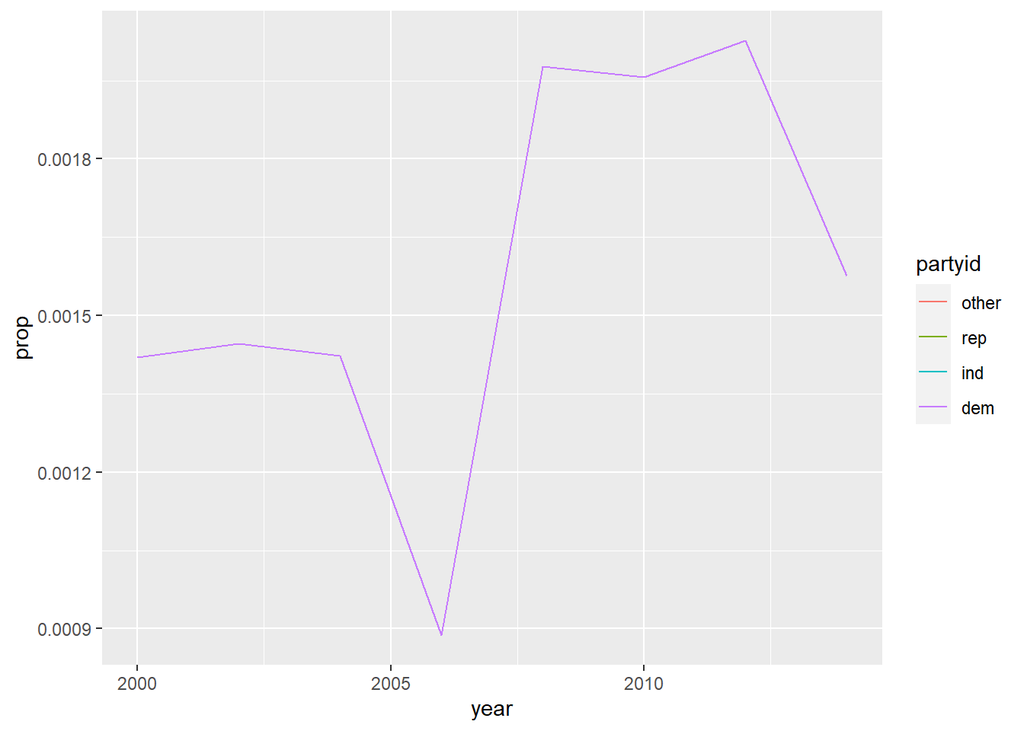

```r
party_time <- gss_cat %>%
  group_by(year) %>%
  mutate(partyid = fct_collapse(partyid,
    other = c("No answer", "Don't know", "Other party"),
    rep = c("Strong republican", "Not str republican"),
    ind = c("Ind,near rep", "Independent", "Ind,near dem"),
    dem = c("Not str democrat", "Strong democrat")
  )) %>%
  count(partyid) %>%
  mutate(prop = n() / sum(n))

ggplot(party_time, aes(x = year, y = prop, colour = partyid)) +
  geom_line()
```

#### 2. Collapsing income into a small set of categories

Could either roll the little ones with lump, or use collapse to decrease the size of the levels. I would suggest widening each reported income bracket.

# Dates and Times

Dates and times aren’t easy. Not all days have 24 hours. Not all years have 365 days. Not all months have the same days. We use lubridate here.

There are three types of date time data: - Date - Time - Date-Time

There is a package called HMS for just times.

You should always use the simplest package to meet your needs, if you only need dates, don’t worry about times.

You can find the date and time with.

```r
today()
```

```
## [1] "2021-11-25"
```

```r
now()
```

```
## [1] "2021-11-25 16:39:26 NZDT"
```

Three ways to create a date time -String -From individual components -From existing date/time

## From strings

```r
ymd("2017-01-31")
```

```
## [1] "2017-01-31"
```

```r
mdy("January 31st, 2017")
```

```
## [1] "2017-01-31"
```

```r
ymd(20170131)
```

```
## [1] "2017-01-31"
```

This shows that we are getting the date from 3 difference strings. When parsing the string like above you are stipulating where the y, m, and d is in the string. Meaning that date recording format i.e. American v rest of the world doesn’t matter so much.

Dates times:

```r
ymd_hms("2017-01-31 20:11:59")
```

```
## [1] "2017-01-31 20:11:59 UTC"
```

```r
ymd_hms("2017-01-31 20:11:59", tz = "Pacific/Auckland")
```

```
## [1] "2017-01-31 20:11:59 NZDT"
```

The same quirk of stipulating the order of characters in the string applies here. Can change order of d,m,y and h,m,s (Where h,m,s means Hours, Minutes, Seconds.) Can also stipulate time zones.

```r
flights %>%
  select(year,month, day, hour, minute) %>%
  mutate(departure = make_datetime(year, month, day, hour, minute))
```

Recalling the modular decomposition of the weird time recordings in the flights dataset from previous workshops

```r
make_datetime_100 <- function(year, month, day, time) {
  make_datetime(year, month, day, time %/% 100, time %% 100)
}

flights_dt <- flights %>%
  filter(!is.na(dep_time), !is.na(arr_time)) %>%
  mutate(
    dep_time = make_datetime_100(year, month, day, dep_time),
    arr_time = make_datetime_100(year, month, day, arr_time),
    sched_dep_time = make_datetime_100(year, month, day, sched_dep_time),
    sched_arr_time = make_datetime_100(year, month, day, sched_arr_time)
  ) %>%
  select(origin, dest, ends_with("delay"), ends_with("time"))

flights_dt
```

In this code we create a function, something we haven’t covered yet. but we have covered the use of modular maths to decompose the hour and mins storage in this case.

This can be visualised. Can comment in code chunks with # The below visulatisation shows the flights per day over time.

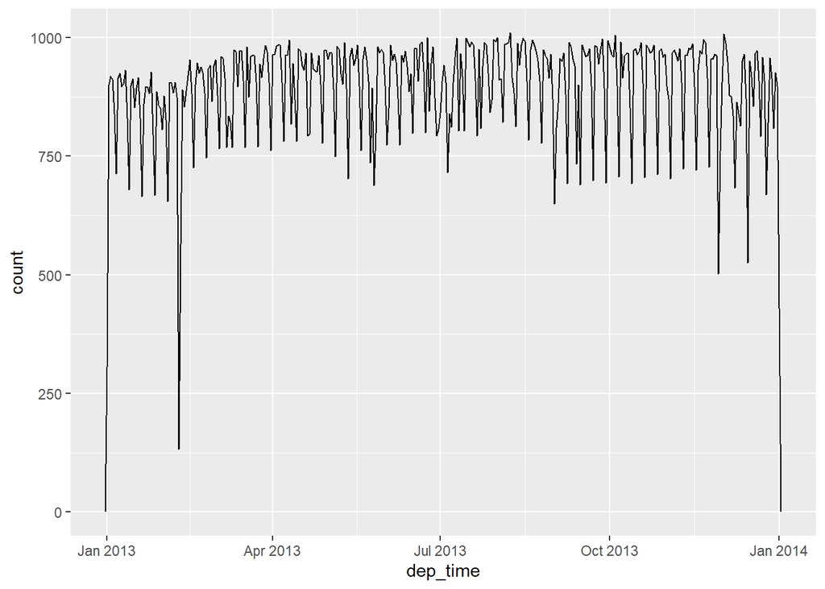

```r
flights_dt %>%
  ggplot(aes(dep_time)) +
  geom_freqpoly(binwidth = 86400) # 86400 seconds = 1 day
```

Flights within a day:

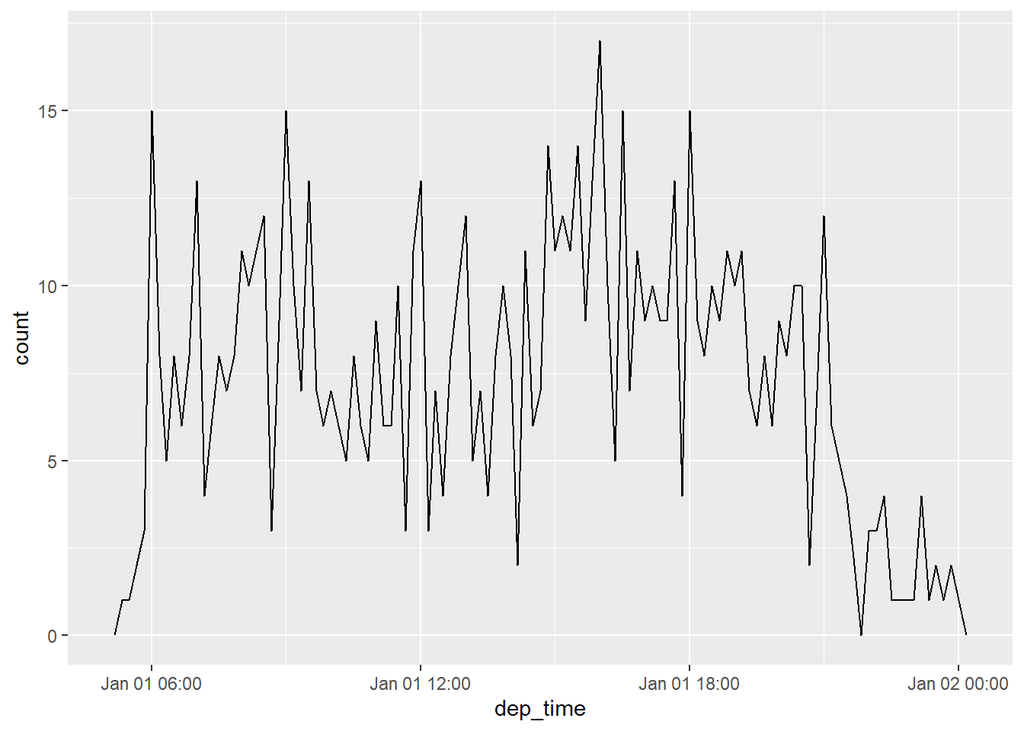

```r
flights_dt %>%
  filter(dep_time < ymd(20130102)) %>%
  ggplot(aes(dep_time)) +
  geom_freqpoly(binwidth = (10*60)) #this is the binwidth for 10 minutes in seconds
```

as_datetime allows you to switch from date to datetime

```r
today()
```

```
## [1] "2021-11-25"
```

```r
as_datetime(today())
```

```
## [1] "2021-11-25 UTC"
```

can also go backwards with as_date

```r
now()
```

```
## [1] "2021-11-25 16:39:31 NZDT"
```

```r
as_date(now())
```

```
## [1] "2021-11-25"
```

### Exercises 16.2.4

#### 1. Parsing string with invalid dates

```r
ymd(c("2010-10-10", "bananas"))
```

```
## [1] "2010-10-10" NA
```

Causes a failure to parse.

#### 2. What does the tzone argument do to today()? Why is it important?

```r
?today()
```

tzone  
a character vector specifying which time zone you would like the current time in. tzone defaults to your computer’s system timezone. You can retrieve the current time in the Universal Coordinated Time (UTC) with now(“UTC”).

This means that using today() and now() could be problematic if working with people in different time zones as it relies on the time zone of the local computer.

#### 3. Parsing the following date time strings

```r
d1 <- "January 1, 2010"
d2 <- "2015-Mar-07"
d3 <- "06-Jun-2017"
d4 <- c("August 19 (2015)", "July 1 (2015)")
d5 <- "12/30/14" # Dec 30, 2014

mdy(d1)
```

```
## [1] "2010-01-01"
```

```r
ymd(d2)
```

```
## [1] "2015-03-07"
```

```r
dmy(d3)
```

```
## [1] "2017-06-06"
```

```r
mdy(d4)
```

```
## [1] "2015-08-19" "2015-07-01"
```

```r
mdy(d5)
```

```
## [1] "2014-12-30"
```

The format to use depends on your use case.

## Date time components

This code shows you calling specific values from the date time

```r
datetime <- ymd_hms("2016-07-08 12:34:56")

year(datetime)
```

```
## [1] 2016
```

```r
month(datetime)
```

```
## [1] 7
```

```r
mday(datetime)
```

```
## [1] 8
```

```r
yday(datetime)
```

```
## [1] 190
```

```r
wday(datetime)
```

```
## [1] 6
```

yday is days since 1/jan. wday is number day of week. can use months as labels, and change if they’re abbreviated or not with T/F arguments.

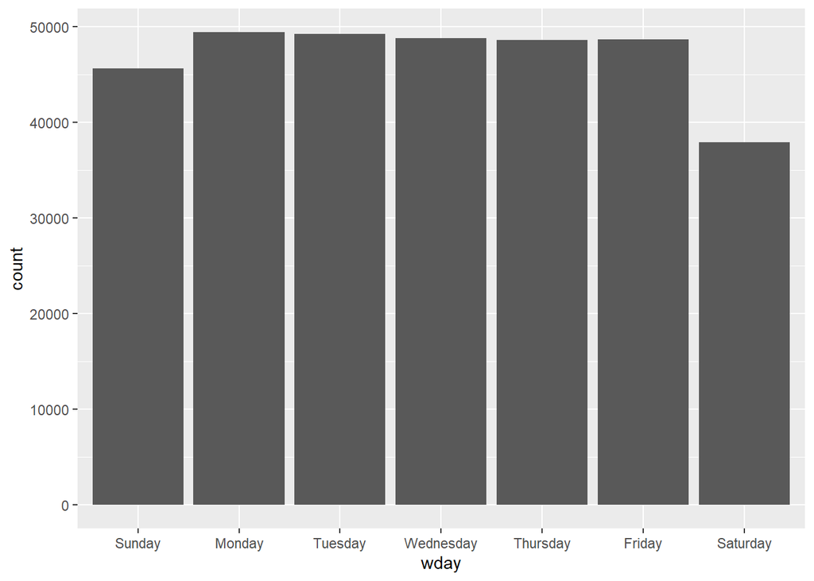

```r
flights_dt %>%
  mutate(wday = wday(dep_time, label = TRUE, abbr = FALSE)) %>%
  ggplot(aes(x = wday)) +
  geom_bar()
```

## Rounding

You can round dates three ways: - Floor(down) - Ceiling (up) - Round_date (round to)

## Time spans

There are three classes - Duration (exact number of seconds) - Periods (human units, i.e. weeks and months) - Intervals (represents start and end point) They all have the uses, duration is most accurate, but not useful if trying to cumulate into months.

### Durations

This uses the authors age to illustrate durations of lubridate.

```r
h_age = today() - ymd(19791014)
h_age
```

```
## Time difference of 15383 days
```

```r
class(h_age)
```

```
## [1] "difftime"
```

```r
as.duration(h_age)
```

```
## [1] "1329091200s (~42.12 years)"
```

You can also could seconds (maths) in various time units

```r
dseconds(15)
```

```
## [1] "15s"
```

```r
dhours(23)
```

```
## [1] "82800s (~23 hours)"
```

```r
dweeks(12)
```

```
## [1] "7257600s (~12 weeks)"
```

### Periods

Lubridate provides periods (human time spans) but don’t have a fixed length in seconds.

Lets use periods to fix the flights data set, which was showing some flights going back in time due to being over night flights.

```r
flights_dt %>%
  filter(arr_time < dep_time)

flights_dt <- flights_dt %>%
  mutate(
    overnight = arr_time < dep_time,
    arr_time = arr_time + days(1 * overnight),
    sched_arr_time = sched_arr_time + days(1 * overnight)
  )
```

### Intervals

```r
dyears(1) / ddays(365)
```

```
## [1] 1.000685
```

Quirk of these is not exactly 1 due to the way time is recorded (daylight savings, leap years etc)

### Summary

If you are getting errors after trying to maniuplate time, perhaps you have specified something correctly.

### Exercises 16.4.5

#### 1. Why is there months() but not dmonths()

Not every month has the same number of days, and thus seconds.

#### 2. Explain (overnight * 1)

We created a binary (0,1) variable for flights that occur overnight. When true = 1, which can be used to manipulate time to account for overnight flights.

#### 3.

Creating a vector of dates for every first day of the month in 2015 (in a code efficient way)

```r
ymd("2015-01-01") + months(0:11)
```

```
##  [1] "2015-01-01" "2015-02-01" "2015-03-01" "2015-04-01" "2015-05-01"
##  [6] "2015-06-01" "2015-07-01" "2015-08-01" "2015-09-01" "2015-10-01"
## [11] "2015-11-01" "2015-12-01"
```

## Time Zones

R can use consistent time zones from IANA in the format “Continent/City”

Can check your current time zone in R.

```r
Sys.timezone()
```

```
## [1] "Pacific/Auckland"
```

There are 593 timezones, they can be found with OlsonNames() Time zone is an attribute of the date time, but only controls printing.

These times are the same, can verify by subtracting.

```r
(x1 <- ymd_hms("2015-06-01 12:00:00", tz = "America/New_York"))
(x2 <- ymd_hms("2015-06-01 18:00:00", tz = "Europe/Copenhagen"))
(x3 <- ymd_hms("2015-06-02 04:00:00", tz = "Pacific/Auckland"))

x1-x2
x2-x3

x4 <- c(x1, x2, x3)
x4
```

[output not shown]